# Exploratory Data Analysis

Author

Kiera Murray

Published

November 22, 2026

# Setup

```r
# Load packages
pacman::p_load(tidyverse, knitr, gtsummary, pacman, grateful, here, usethis)
```

```r
# Set blank slate
usethis::use_blank_slate(scope = "user")

# Citations
grateful::cite_packages(pkgs='Session', output='paragraph', out.dir='.')
```

We used R v. 4.5.2 [@base] and the following R packages: gtsummary v. 2.6.1 [@gtsummary], here v. 1.0.2 [@here], knitr v. 1.51 [@knitr2014; @knitr2015; @knitr2025], pacman v. 0.5.1 [@pacman], tidyverse v. 2.0.0 [@tidyverse], usethis v. 3.2.2 [@usethis].

```r
print(paste("operating system: ", sessionInfo()$running))
```

```
[1] "operating system:  macOS Tahoe 26.5.2"
```

```r
# Check working directory
here()
```

```
[1] "/Users/kieramurray/Library/CloudStorage/OneDrive-Personal/Grad School/Biostats in Action/BIOSTATS-690E-Capstone"
```

# Part 1: EDA on the original data (all headache types)

I don’t plan to put anything from this section in the final manuscript, it’s just for my own reference.

## General summary

```r
# Summarize the original data
load(here("data", "processed", "acupunc_full.RData"))
summary(acupunc_full)
```

```
       id           age            sex              migraine     chronicity
 100    :  1   Min.   :18.00   female:337   migraine    :377   Min.   : 1.00
 101    :  1   1st Qu.:39.00   male  : 64   tension-type: 24   1st Qu.:10.00
 104    :  1   Median :48.00                                   Median :20.00
 105    :  1   Mean   :45.54                                   Mean   :21.46
 108    :  1   3rd Qu.:53.00                                   3rd Qu.:31.00
 112    :  1   Max.   :65.00                                   Max.   :54.00
 (Other):395
 acupuncturist         group          pk1             pk2
 3      :91    acupuncture:205   Min.   : 6.75   Min.   : 0.00
 8      :61    control    :196   1st Qu.:15.00   1st Qu.:10.75
 6      :56                      Median :21.00   Median :16.88
 7      :38                      Mean   :26.51   Mean   :21.60
 9      :36                      3rd Qu.:34.25   3rd Qu.:27.00
 11     :34                      Max.   :94.75   Max.   :98.50
 (Other):85                                      NA's   :75
      pk5              f1              f2              f5               gp
 Min.   : 0.00   Min.   : 3.00   Min.   : 0.00   Min.   : 0.000   18     : 43
 1st Qu.: 8.50   1st Qu.:10.00   1st Qu.: 4.00   1st Qu.: 0.000   12     : 37
 Median :15.00   Median :15.00   Median :10.00   Median : 8.000   41     : 32
 Mean   :19.08   Mean   :16.18   Mean   :10.94   Mean   : 9.319   10     : 24
 3rd Qu.:25.25   3rd Qu.:21.00   3rd Qu.:17.00   3rd Qu.:14.000   16     : 22
 Max.   :87.25   Max.   :28.00   Max.   :28.00   Max.   :28.000   40     : 22
 NA's   :100                                                      (Other):221
```

## How many patients to each acupuncturist?

```r
# calculate and print
patients_per_acu_full <- acupunc_full %>%
  # consider only patients who received acupuncture:
  filter(group == "acupuncture") %>%
  group_by(acupuncturist) %>% summarize(n_patients = n())
kable(patients_per_acu_full)
```

| acupuncturist | n_patients |
| --- | --- |
| 1 | 1 |
| 2 | 17 |
| 3 | 45 |
| 4 | 15 |
| 5 | 7 |
| 6 | 28 |
| 7 | 20 |
| 8 | 32 |
| 9 | 19 |
| 10 | 3 |
| 11 | 17 |
| 12 | 1 |

```r
# quantiles
quantile(patients_per_acu_full$n_patients)
```

```
  0%  25%  50%  75% 100%
   1    6   17   22   45
```

12 total acupuncturists, ranging from 1 to 45 patients per acupuncturist.

## How many patients to each GP?

```r
# calculate and print
patients_per_gp_full <- acupunc_full %>%
  group_by(gp) %>% summarize(n_patients = n())
kable(patients_per_gp_full)
```

| gp | n_patients |
| --- | --- |
| 10 | 24 |
| 11 | 15 |
| 12 | 37 |
| 15 | 16 |
| 16 | 22 |
| 17 | 13 |
| 18 | 43 |
| 19 | 3 |
| 20 | 4 |
| 21 | 20 |
| 22 | 14 |
| 23 | 17 |
| 24 | 4 |
| 25 | 15 |
| 26 | 6 |
| 27 | 7 |
| 28 | 7 |
| 29 | 1 |
| 30 | 5 |
| 32 | 2 |
| 33 | 19 |
| 34 | 9 |
| 35 | 3 |
| 37 | 6 |
| 38 | 6 |
| 40 | 22 |
| 41 | 32 |
| 42 | 17 |
| 44 | 4 |
| 45 | 2 |
| 52 | 1 |
| 53 | 1 |
| 54 | 1 |
| 55 | 1 |
| 56 | 1 |
| 58 | 1 |

```r
# quantiles
quantile(patients_per_gp_full$n_patients)
```

```
   0%   25%   50%   75%  100%
 1.00  2.75  6.50 17.00 43.00
```

36 total GPs, ranging from 1 to 43 patients per GP.

## How many patients by sex and headache type?

```r
# How many patients by sex and headache type?
sexheadache <- acupunc_full %>%
  group_by(sex, migraine) %>% summarize(n())
```

```
`summarise()` has regrouped the output.
ℹ Summaries were computed grouped by sex and migraine.
ℹ Output is grouped by sex.
ℹ Use `summarise(.groups = "drop_last")` to silence this message.
ℹ Use `summarise(.by = c(sex, migraine))` for per-operation grouping
  (`?dplyr::dplyr_by`) instead.
```

```r
kable(sexheadache)
```

| sex | migraine | n() |
| --- | --- | --- |
| female | migraine | 318 |
| female | tension-type | 19 |
| male | migraine | 59 |
| male | tension-type | 5 |

# Part 2: EDA on the migraine-only data

## General summary

```r
# Summarize the data
load(here("data", "processed", "acupunc.RData"))
summary(acupunc)
```

```
       id           age            sex              migraine     chronicity
 100    :  1   Min.   :18.00   female:318   migraine    :377   Min.   : 1.00
 101    :  1   1st Qu.:38.00   male  : 59   tension-type:  0   1st Qu.:10.00
 104    :  1   Median :48.00                                   Median :20.00
 105    :  1   Mean   :45.42                                   Mean   :21.86
 108    :  1   3rd Qu.:53.00                                   3rd Qu.:31.00
 112    :  1   Max.   :65.00                                   Max.   :54.00
 (Other):371
 acupuncturist         group          pk1             pk2
 3      :83    acupuncture:194   Min.   : 6.75   Min.   : 0.00
 8      :58    control    :183   1st Qu.:15.00   1st Qu.:10.75
 6      :54                      Median :21.25   Median :16.75
 7      :37                      Mean   :26.61   Mean   :21.42
 9      :34                      3rd Qu.:34.50   3rd Qu.:27.06
 11     :32                      Max.   :94.75   Max.   :98.50
 (Other):79                                      NA's   :69
      pk5              f1              f2              f5               gp
 Min.   : 0.00   Min.   : 3.00   Min.   : 0.00   Min.   : 0.000   18     : 41
 1st Qu.: 8.25   1st Qu.:10.00   1st Qu.: 4.00   1st Qu.: 0.000   12     : 31
 Median :15.00   Median :15.00   Median :10.00   Median : 8.000   41     : 30
 Mean   :18.96   Mean   :16.14   Mean   :10.96   Mean   : 9.265   10     : 23
 3rd Qu.:25.06   3rd Qu.:21.00   3rd Qu.:17.00   3rd Qu.:14.000   16     : 22
 Max.   :87.25   Max.   :28.00   Max.   :28.00   Max.   :28.000   40     : 20
 NA's   :93                                                       (Other):210
```

```r
# Create Table 1, which lists baseline characteristics by treatment group
table1 <- acupunc %>% tbl_summary(
  include = c(age, sex, chronicity, pk1),
  missing_stat = "{N_miss} ({p_miss}%)", # show % missing
  by = group)
table1
```

| **Characteristic** | **acupuncture** N = 194<sup>1</sup> | **control** N = 183<sup>1</sup> |
| --- | --- | --- |
| age | 48 (41, 53) | 48 (36, 54) |
| sex |  |  |
| female | 165 (85%) | 153 (84%) |
| male | 29 (15%) | 30 (16%) |
| chronicity | 20 (10, 31) | 20 (10, 31) |
| pk1 | 21 (15, 33) | 22 (16, 36) |

<sup>1</sup> Median (Q1, Q3); n (%)

```r
# Potentially interesting: characteristics by sex
# (won't go in manuscript, just for my reference)
table1sex <- acupunc %>% tbl_summary(
  include = c(age, group, chronicity, pk1, pk2, pk5),
  missing_stat = "{N_miss} ({p_miss}%)", # show % missing
  by = sex)
table1sex
```

| **Characteristic** | **female** N = 318<sup>1</sup> | **male** N = 59<sup>1</sup> |
| --- | --- | --- |
| age | 47 (38, 53) | 49 (39, 55) |
| group |  |  |
| acupuncture | 165 (52%) | 29 (49%) |
| control | 153 (48%) | 30 (51%) |
| chronicity | 20 (10, 31) | 20 (8, 36) |
| pk1 | 22 (15, 35) | 20 (15, 34) |
| pk2 | 17 (11, 27) | 15 (9, 24) |
| Unknown | 54 (17%) | 15 (25%) |
| pk5 | 15 (9, 25) | 14 (8, 30) |
| Unknown | 77 (24%) | 16 (27%) |

<sup>1</sup> Median (Q1, Q3); n (%)

## Acupuncturist breakdown

### Numbers of patients and GPs

```r
# How many patients and GPs to each acupuncturist?
patients_per_acu <- acupunc %>%

  # consider only patients who received acupuncture
  filter(group == "acupuncture") %>%

  # first, get number of patients per acupuncturist/GP combination
  group_by(acupuncturist, gp) %>%
  summarize(obs = n()) %>%

  # then collapse to number of patients and number of GPs
  group_by(acupuncturist) %>%
  summarize(n_patients = sum(obs), n_GPs = n())
```

```
`summarise()` has regrouped the output.
ℹ Summaries were computed grouped by acupuncturist and gp.
ℹ Output is grouped by acupuncturist.
ℹ Use `summarise(.groups = "drop_last")` to silence this message.
ℹ Use `summarise(.by = c(acupuncturist, gp))` for per-operation grouping
  (`?dplyr::dplyr_by`) instead.
```

```r
# View results
kable(patients_per_acu)
```

| acupuncturist | n_patients | n_GPs |
| --- | --- | --- |
| 1 | 1 | 1 |
| 2 | 15 | 4 |
| 3 | 42 | 5 |
| 4 | 14 | 5 |
| 5 | 7 | 2 |
| 6 | 28 | 2 |
| 7 | 19 | 2 |
| 8 | 30 | 4 |
| 9 | 18 | 3 |
| 10 | 3 | 1 |
| 11 | 16 | 3 |
| 12 | 1 | 1 |

```r
# Quantiles of n_patients per acupuncturist
quantile(patients_per_acu$n_patients)
```

```
   0%   25%   50%   75%  100%
 1.00  6.00 15.50 21.25 42.00
```

```r
# Quantiles of n_GPs per acupuncturist
quantile(patients_per_acu$n_GPs)
```

```
  0%  25%  50%  75% 100%
1.00 1.75 2.50 4.00 5.00
```

12 total acupuncturists, ranging from 1 to 42 patients per acupuncturist and 1 to 5 GPs per acupuncturist.

I’ll probably just put this quantile info in the manuscript, no need for the full table.

### Missingness

Table to show the distribution of missing data:

```r
acupunc_acu_only <- acupunc %>% filter(group == "acupuncture")

table_missing_acupuncture <- acupunc_acu_only %>%
  tbl_summary(
    include = c(pk1, pk2, pk5),
    missing_stat = "{N_miss} ({p_miss}%)", # show % missing
    by = acupuncturist
  )
table_missing_acupuncture
```

| **Characteristic** | **1** N = 1<sup>1</sup> | **2** N = 15<sup>1</sup> | **3** N = 42<sup>1</sup> | **4** N = 14<sup>1</sup> | **5** N = 7<sup>1</sup> | **6** N = 28<sup>1</sup> | **7** N = 19<sup>1</sup> | **8** N = 30<sup>1</sup> | **9** N = 18<sup>1</sup> | **10** N = 3<sup>1</sup> | **11** N = 16<sup>1</sup> | **12** N = 1<sup>1</sup> |
| --- | --- | --- | --- | --- | --- | --- | --- | --- | --- | --- | --- | --- |
| pk1 | 21 (21, 21) | 31 (21, 48) | 19 (13, 32) | 27 (18, 32) | 25 (11, 49) | 23 (17, 30) | 18 (13, 22) | 17 (13, 36) | 20 (12, 35) | 37 (36, 38) | 22 (17, 28) | 11 (11, 11) |
| pk2 | 23 (23, 23) | 11 (9, 24) | 13 (7, 21) | 12 (6, 23) | 22 (11, 27) | 18 (13, 27) | 14 (10, 17) | 16 (9, 31) | 14 (7, 18) | 27 (19, 29) | 15 (7, 28) | NA (NA, NA) |
| Unknown | 0 (0%) | 4 (27%) | 5 (12%) | 2 (14%) | 1 (14%) | 5 (18%) | 0 (0%) | 3 (10%) | 4 (22%) | 0 (0%) | 5 (31%) | 1 (100%) |
| pk5 | 11 (11, 11) | 13 (6, 18) | 10 (6, 15) | 11 (8, 23) | 19 (10, 27) | 14 (10, 20) | 13 (3, 17) | 10 (6, 27) | 12 (10, 25) | 16 (11, 21) | 15 (10, 24) | NA (NA, NA) |
| Unknown | 0 (0%) | 6 (40%) | 8 (19%) | 2 (14%) | 1 (14%) | 7 (25%) | 2 (11%) | 5 (17%) | 4 (22%) | 1 (33%) | 5 (31%) | 1 (100%) |

<sup>1</sup> Median (Q1, Q3)

Barchart to show the distribution of missing data:

```r
# Create a dataframe with complete cases information
acu_missing <- acupunc %>%
  filter(group == "acupuncture") %>%
  mutate(complete = (!is.na(pk2) & !is.na(pk5))) %>%
  group_by(acupuncturist, group, complete) %>%
  summarise(count = n())
```

```
`summarise()` has regrouped the output.
ℹ Summaries were computed grouped by acupuncturist, group, and complete.
ℹ Output is grouped by acupuncturist and group.
ℹ Use `summarise(.groups = "drop_last")` to silence this message.
ℹ Use `summarise(.by = c(acupuncturist, group, complete))` for per-operation
  grouping (`?dplyr::dplyr_by`) instead.
```

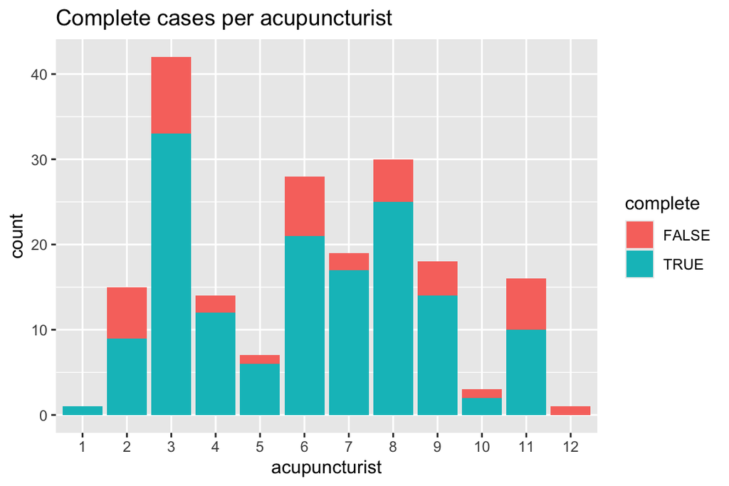

```r
# Generate barchart
ggplot(data = acu_missing, mapping = aes(x = acupuncturist, y = count, fill = complete))+
  geom_col()+
  ggtitle("Complete cases per acupuncturist")
```

Overall it looks like missingness won’t be a huge issue, since it’s pretty evenly distributed across acupuncturist. Therefore, no need to put any missingmess visualizations in the final manuscript.

### Outcome visualizations

Spaghetti plot to visualize average scores over time:

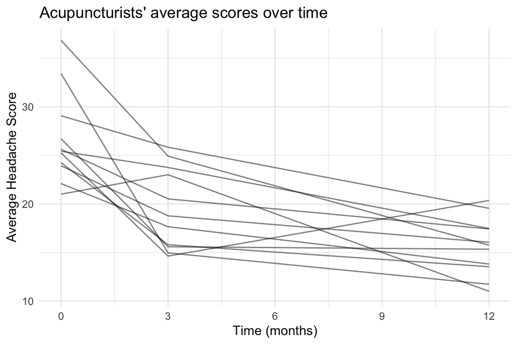

```r
# Create a dataframe for visualization
acu_scores <- acupunc %>%
  filter(group == "acupuncture") %>%
  group_by(acupuncturist) %>%
  summarize(
    pk1_avg = mean(pk1),
    pk2_avg = mean(pk2, na.rm = TRUE),
    pk5_avg = mean(pk5, na.rm = TRUE)
  ) %>%
  pivot_longer(cols = c(pk1_avg, pk2_avg, pk5_avg),
               names_to = "pk", values_to = "avg_score") %>%
  mutate(time = case_when(
    pk == "pk1_avg" ~ 0,
    pk == "pk2_avg" ~ 3,
    pk == "pk5_avg" ~ 12,
    .default = NA # value when no above condition is matched
  ))

# Create the visualization
ggplot(acu_scores, aes(x=time))+
  geom_line(aes(y=avg_score, group=acupuncturist), alpha=0.5)+
  scale_x_continuous(breaks = seq(0, 12, by=3))+
  theme_minimal()+
  labs(title = "Acupuncturists' average scores over time",
       x = "Time (months)", y = "Average Headache Score")
```

Boxplot to visualize the change in score for each acupuncturist

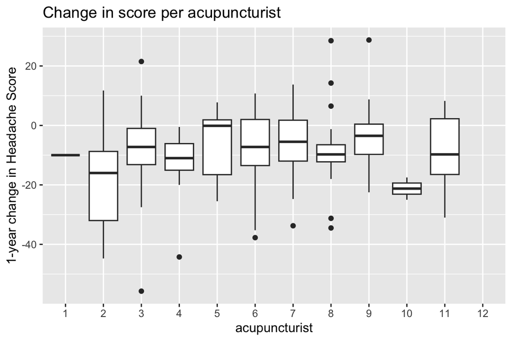

```r
acu_diffs <- acupunc %>%
  filter(group == "acupuncture") %>%
  mutate(difference = pk5 - pk1)

ggplot(data = acu_diffs, mapping = aes(x = acupuncturist, y = difference))+
  geom_boxplot()+
  labs(y = "1-year change in Headache Score",
       title = "Change in score per acupuncturist")
```

These plots show that acupuncturists are all somewhat similar to each other.

## GP breakdown

### Numbers of patients (total and per group) and assigned acupuncturist

```r
# How many patients to each GP?
patients_per_gp <- acupunc %>%

  # get number of patients per GP and group, keeping the assigned acup'ist column
  rename(assigned_acupist = acupuncturist) %>% # more informative column name
  group_by(gp, assigned_acupist, group) %>%
  summarize(n_patients = n()) %>%

  # create columns for number of patients per treatment group
  pivot_wider(names_from = group, values_from = n_patients) %>%
  rename(n_patients_acup = acupuncture) %>%
  rename(n_patients_control = control) %>%
  # replace NAs with 0s:
  mutate(n_patients_acup = replace_na(n_patients_acup, 0)) %>%
  mutate(n_patients_control = replace_na(n_patients_control, 0)) %>%

  # create a column for total number of patients (per GP)
  mutate(n_patients_total = sum(n_patients_acup, n_patients_control))
```

```
`summarise()` has regrouped the output.
ℹ Summaries were computed grouped by gp, assigned_acupist, and group.
ℹ Output is grouped by gp and assigned_acupist.
ℹ Use `summarise(.groups = "drop_last")` to silence this message.
ℹ Use `summarise(.by = c(gp, assigned_acupist, group))` for per-operation
  grouping (`?dplyr::dplyr_by`) instead.
```

```r
# View results
kable(patients_per_gp)
```

| gp | assigned_acupist | n_patients_acup | n_patients_control | n_patients_total |
| --- | --- | --- | --- | --- |
| 10 | 3 | 12 | 11 | 23 |
| 11 | 3 | 9 | 6 | 15 |
| 12 | 3 | 14 | 17 | 31 |
| 15 | 7 | 7 | 8 | 15 |
| 16 | 7 | 12 | 10 | 22 |
| 17 | 6 | 8 | 5 | 13 |
| 18 | 6 | 20 | 21 | 41 |
| 19 | 8 | 2 | 1 | 3 |
| 20 | 4 | 1 | 1 | 2 |
| 21 | 4 | 9 | 10 | 19 |
| 22 | 3 | 6 | 7 | 13 |
| 23 | 9 | 10 | 7 | 17 |
| 24 | 9 | 1 | 2 | 3 |
| 25 | 9 | 7 | 7 | 14 |
| 26 | 5 | 4 | 2 | 6 |
| 27 | 8 | 3 | 4 | 7 |
| 28 | 5 | 3 | 3 | 6 |
| 29 | 4 | 1 | 0 | 1 |
| 30 | 4 | 2 | 3 | 5 |
| 32 | 2 | 1 | 1 | 2 |
| 33 | 2 | 9 | 8 | 17 |
| 34 | 2 | 4 | 5 | 9 |
| 35 | 12 | 1 | 2 | 3 |
| 37 | 11 | 3 | 3 | 6 |
| 38 | 11 | 3 | 3 | 6 |
| 40 | 11 | 10 | 10 | 20 |
| 41 | 8 | 15 | 15 | 30 |
| 42 | 8 | 10 | 7 | 17 |
| 44 | 10 | 3 | 1 | 4 |
| 45 | 1 | 1 | 1 | 2 |
| 52 | 2 | 1 | 0 | 1 |
| 54 | 8 | 0 | 1 | 1 |
| 55 | 3 | 1 | 0 | 1 |
| 56 | 10 | 0 | 1 | 1 |
| 58 | 4 | 1 | 0 | 1 |

```r
# Quantiles of total number of patients per GP
quantile(patients_per_gp$n_patients_total)
```

```
  0%  25%  50%  75% 100%
 1.0  2.5  6.0 17.0 41.0
```

```r
# Quantiles of acupuncture group patients per GP
quantile(patients_per_gp$n_patients_acup)
```

```
  0%  25%  50%  75% 100%
   0    1    3    9   20
```

```r
# Quantiles of control group patients per GP
quantile(patients_per_gp$n_patients_control)
```

```
  0%  25%  50%  75% 100%
 0.0  1.0  3.0  7.5 21.0
```

35 total GPs, ranging from 1 to 41 total patients per GP, with 0-20 acupuncture patients and 0-21 control patients.

Again, I’ll probably just put this quantile info in the manuscript, no need for the full table.

### Missingness

Barchart to show the distribution of missing data:

```r
# Create a dataframe with complete cases information
gp_missing <- acupunc %>%
  mutate(complete = (!is.na(pk2) & !is.na(pk5))) %>%
  group_by(gp, group, complete) %>%
  summarise(count = n()) %>%
  mutate(case_type = case_when(
    group == "acupuncture" & complete == TRUE ~ "acupuncture - complete",
    group == "acupuncture" & complete == FALSE ~ "acupuncture - incomplete",
    group == "control" & complete == TRUE ~ "control - complete",
    group == "control" & complete == FALSE ~ "control - incomplete",
    .default = NA # value when no above condition is matched
  ))
```

```
`summarise()` has regrouped the output.
ℹ Summaries were computed grouped by gp, group, and complete.
ℹ Output is grouped by gp and group.
ℹ Use `summarise(.groups = "drop_last")` to silence this message.
ℹ Use `summarise(.by = c(gp, group, complete))` for per-operation grouping
  (`?dplyr::dplyr_by`) instead.
```

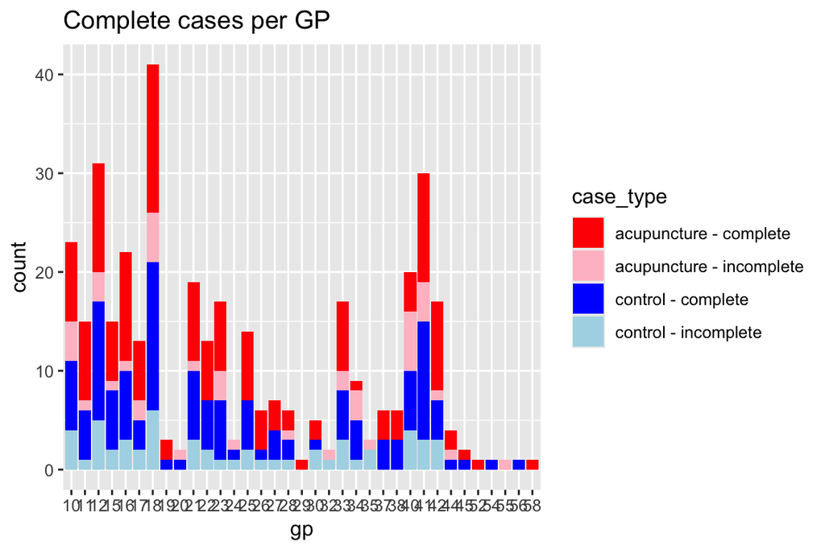

```r
# Generate barchart
ggplot(data = gp_missing, mapping =
         aes(x = gp, y = count, fill = case_type))+
  geom_col()+
  scale_fill_manual(values = c("acupuncture - complete" = "red",
                               "acupuncture - incomplete" = "pink",
                               "control - complete" = "blue",
                               "control - incomplete" = "lightblue"))+
  ggtitle("Complete cases per GP")
```

Sorry about the ugly colors! Like the acupuncturist version, missingness appears to be pretty evenly distributed across GP. Therefore it shouldn’t be a major issue, so no need to put any missingmess visualizations in the final manuscript.

### Outcome visualizations

Spaghetti plot to visualize average scores over time:

```r
# Create a dataframe for visualization
gp_scores <- acupunc %>%
  group_by(gp, group) %>%
  summarize(
    pk1_avg = mean(pk1),
    pk2_avg = mean(pk2, na.rm = TRUE),
    pk5_avg = mean(pk5, na.rm = TRUE)
  ) %>%
  pivot_longer(cols = c(pk1_avg, pk2_avg, pk5_avg),
               names_to = "pk", values_to = "avg_score") %>%
  mutate(time = case_when(
    pk == "pk1_avg" ~ 0,
    pk == "pk2_avg" ~ 3,
    pk == "pk5_avg" ~ 12,
    .default = NA # value when no above condition is matched
  )) %>%
  mutate(gp_group = paste0(gp, group))
```

```
`summarise()` has regrouped the output.
ℹ Summaries were computed grouped by gp and group.
ℹ Output is grouped by gp.
ℹ Use `summarise(.groups = "drop_last")` to silence this message.
ℹ Use `summarise(.by = c(gp, group))` for per-operation grouping
  (`?dplyr::dplyr_by`) instead.
```

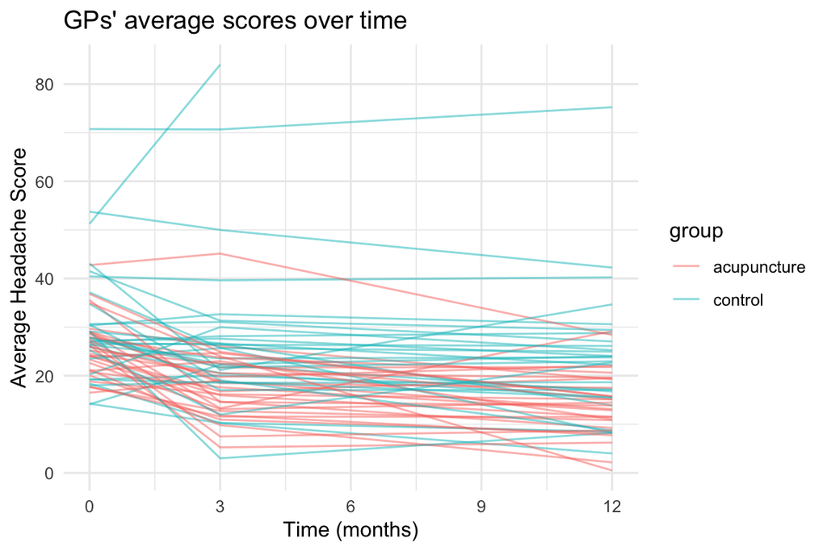

```r
# Create the visualization
ggplot(gp_scores, aes(x=time))+
  geom_line(aes(y=avg_score, group=gp_group, color=group), alpha=0.5)+
  scale_x_continuous(breaks = seq(0, 12, by=3))+
  theme_minimal()+
  labs(title = "GPs' average scores over time",
       x = "Time (months)", y = "Average Headache Score")
```

We can see that scores for the acupuncture group tend to be lower than for the GP group, and that acupuncture scores also tend to drop faster. There are a few (probably small) outlier GPs with unsusally high scores, but overall most GPs’ scores are pretty similar to each other.

Boxplot to visualize the change in score for each GP

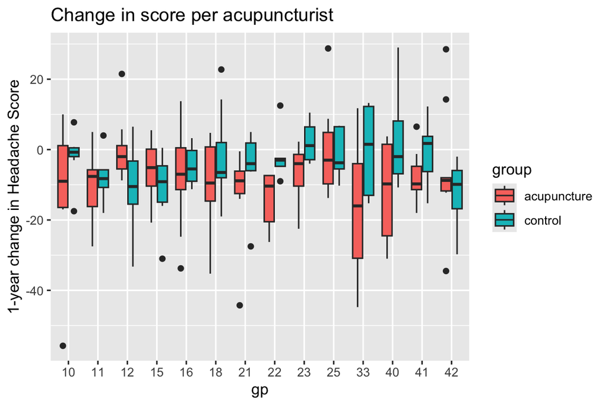

```r
gp_diffs <- acupunc %>%
  mutate(difference = pk5 - pk1) %>%
  mutate(observed = ifelse(is.na(difference), 0, 1)) %>%
  group_by(gp) %>%
  mutate(gp_obs = sum(observed)) %>%
  ungroup() %>%
  filter(gp_obs >= 10) # keep only GPs with a decent number of observations

ggplot(data = gp_diffs, mapping = aes(x = gp, y = difference, fill=group))+
  geom_boxplot()+
  labs(y = "1-year change in Headache Score",
       title = "Change in score per acupuncturist")
```

We can see that among this set of GPs, there’s isn’t huge variation from one GP to another. Most GPs show a decrease in scores for the treatment group, and all show a decrease for the acupuncture group. For a given GP, the acupuncture patients usually (but not always) experience a greater decrease in score than the control patients.

### Do GPs have an even split between acupuncture and control patients?

I’m not planning to put this analysis in the manuscript, but I’m curious about the few GPs that don’t have a perfectly even split between acupuncture and control patients. Is there anything going on that I should be worried about?

```r
patients_per_gp_uneven <- patients_per_gp %>%
  # look at only GPs with an uneven split:
  filter(abs(n_patients_acup - n_patients_control) > 1) %>%
  # which group is bigger?
  mutate(acup_greater = n_patients_acup > n_patients_control)

kable(patients_per_gp_uneven)
```

| gp | assigned_acupist | n_patients_acup | n_patients_control | n_patients_total | acup_greater |
| --- | --- | --- | --- | --- | --- |
| 11 | 3 | 9 | 6 | 15 | TRUE |
| 12 | 3 | 14 | 17 | 31 | FALSE |
| 16 | 7 | 12 | 10 | 22 | TRUE |
| 17 | 6 | 8 | 5 | 13 | TRUE |
| 23 | 9 | 10 | 7 | 17 | TRUE |
| 26 | 5 | 4 | 2 | 6 | TRUE |
| 42 | 8 | 10 | 7 | 17 | TRUE |
| 44 | 10 | 3 | 1 | 4 | TRUE |

Most GPs have an even split between acupuncture and control patients (defined as a difference of 0 or 1 between the group sizes). However, of those with an uneven split, most have more patients in the acupuncture group. Overall, there are 11 more patients total in the acupuncture group than in the control group.

This 11-person difference is similar to the difference in groups before removing tension-type patients (9 more people in acupuncture). Furthermore, the publicly available data includes all 401 patients who were randomized, including those missing follow-up data. Therefore, I conclude that the disparity in acupuncture vs. control group numbers was present at the time of randomization and is not a result of my data processing. In conlusion: nothing to worry about here!